# Kobe Shot Prediction

Team 3

4/18/2021

### Summary & Background

#### Summary

- Action_type (i.e. dunk, shot, alley oop)
- combined shot type (i.e. bank shot , dunk)
- game_event_id
- game_id
- lat
- loc_x
- loc_y
- lon
- minutes remaining
- period
- playoffs
- season
- seconds_remaining
- shot_distance
- shot_made_flag
- shot zone
- shot zone basic (ex. Restricted Area)
- shot zone range
- team id
- team_name
- game date
- matchup
- opponent
- shot_id
- time remaining

#### Load in Data

```r
# Read in dataset
kobe.orignal= read.csv("data.csv" , stringsAsFactors = TRUE)
summary(kobe.orignal)# summary of whole dataset
```

```
##                action_type    combined_shot_type game_event_id
##  Jump Shot           :18880   Bank Shot:  141    Min.   :  2.0
##  Layup Shot          : 2567   Dunk     : 1286    1st Qu.:110.0
##  Driving Layup Shot  : 1978   Hook Shot:  153    Median :253.0
##  Turnaround Jump Shot: 1057   Jump Shot:23485    Mean   :249.2
##  Fadeaway Jump Shot  : 1048   Layup    : 5448    3rd Qu.:368.0
##  Running Jump Shot   :  926   Tip Shot :  184    Max.   :659.0
##  (Other)             : 4241
##     game_id              lat            loc_x              loc_y
##  Min.   :20000012   Min.   :33.25   Min.   :-250.000   Min.   :-44.00
##  1st Qu.:20500077   1st Qu.:33.88   1st Qu.: -68.000   1st Qu.:  4.00
##  Median :20900354   Median :33.97   Median :   0.000   Median : 74.00
##  Mean   :24764066   Mean   :33.95   Mean   :   7.111   Mean   : 91.11
##  3rd Qu.:29600474   3rd Qu.:34.04   3rd Qu.:  95.000   3rd Qu.:160.00
##  Max.   :49900088   Max.   :34.09   Max.   : 248.000   Max.   :791.00
##
##       lon         minutes_remaining     period         playoffs
##  Min.   :-118.5   Min.   : 0.000    Min.   :1.000   Min.   :0.0000
##  1st Qu.:-118.3   1st Qu.: 2.000    1st Qu.:1.000   1st Qu.:0.0000
##  Median :-118.3   Median : 5.000    Median :3.000   Median :0.0000
##  Mean   :-118.3   Mean   : 4.886    Mean   :2.519   Mean   :0.1466
##  3rd Qu.:-118.2   3rd Qu.: 8.000    3rd Qu.:3.000   3rd Qu.:0.0000
##  Max.   :-118.0   Max.   :11.000    Max.   :7.000   Max.   :1.0000
##
##      season      seconds_remaining shot_distance   shot_made_flag
##  2005-06: 2318   Min.   : 0.00     Min.   : 0.00   Min.   :0.000
##  2008-09: 2242   1st Qu.:13.00     1st Qu.: 5.00   1st Qu.:0.000
##  2002-03: 2241   Median :28.00     Median :15.00   Median :0.000
##  2007-08: 2153   Mean   :28.37     Mean   :13.44   Mean   :0.446
##  2009-10: 2080   3rd Qu.:43.00     3rd Qu.:21.00   3rd Qu.:1.000
##  2001-02: 2028   Max.   :59.00     Max.   :79.00   Max.   :1.000
##  (Other):17635                                     NA's   :5000
##           shot_type                   shot_zone_area
##  2PT Field Goal:24271   Back Court(BC)       :   83
##  3PT Field Goal: 6426   Center(C)            :13455
##                         Left Side Center(LC) : 4044
##                         Left Side(L)         : 3751
##                         Right Side Center(RC): 4776
##                         Right Side(R)        : 4588
##
```

[output cut: 9 more lines]

```
##  Los Angeles Lakers:30697   2016-04-13:   50   LAL @ SAS  : 1020
##                             2002-11-07:   47   LAL vs. SAS:  936
##                             2006-01-22:   46   LAL @ SAC  :  889
##                             2006-12-29:   45   LAL vs. HOU:  878
##                             2007-03-30:   44   LAL @ DEN  :  873
##                             2008-01-14:   44   LAL @ PHX  :  859
##                             (Other)   :30421   (Other)    :25242
##     opponent        shot_id
##  SAS    : 1978   Min.   :    1
##  PHX    : 1781   1st Qu.: 7675
##  HOU    : 1666   Median :15349
##  SAC    : 1643   Mean   :15349
##  DEN    : 1642   3rd Qu.:23023
##  POR    : 1539   Max.   :30697
##  (Other):20448
```

```r
# Adding a better variable for measuring time = total time in seconds
kobe.orignal$time_remaining = (kobe.orignal$minutes_remaining*60) + kobe.orignal$seconds_remaining

# Adding a variable to track season, just as a 2 digit year like 97 or 01
library(stringr)
kobe.orignal$season = sapply(kobe.orignal$season, function(x){str_extract(x, "(?<=[:punct:])[:digit:]{2}")})

# To help with confining predictions to shots already taken, converting 2 digit to 4 digit
unique(kobe.orignal$season)
```

```
##  [1] "01" "02" "03" "04" "05" "06" "07" "08" "09" "10" "11" "12" "13" "14" "15"
## [16] "16" "97" "98" "99" "00"
```

```r
kobe.orignal$season <- sapply(kobe.orignal$season, function(x){if(x > 96){paste0("19",x)}else{paste0("20",x)}})
unique(kobe.orignal$season)
```

```
##  [1] "2001" "2002" "2003" "2004" "2005" "2006" "2007" "2008" "2009" "2010"
## [11] "2011" "2012" "2013" "2014" "2015" "2016" "1997" "1998" "1999" "2000"
```

### Data Preproccesing

#### Converting Shots Taken and Remove Team Columns

```
##  [1] Jump Shot                          Driving Dunk Shot
##  [3] Layup Shot                         Running Jump Shot
##  [5] Driving Layup Shot                 Reverse Layup Shot
##  [7] Reverse Dunk Shot                  Slam Dunk Shot
##  [9] Turnaround Jump Shot               Tip Shot
## [11] Running Hook Shot                  Alley Oop Dunk Shot
## [13] Dunk Shot                          Alley Oop Layup shot
## [15] Running Dunk Shot                  Driving Finger Roll Shot
## [17] Running Layup Shot                 Finger Roll Shot
## [19] Fadeaway Jump Shot                 Follow Up Dunk Shot
## [21] Hook Shot                          Turnaround Hook Shot
## [23] Running Tip Shot                   Jump Hook Shot
## [25] Running Finger Roll Shot           Jump Bank Shot
## [27] Turnaround Finger Roll Shot        Hook Bank Shot
## [29] Driving Hook Shot                  Running Reverse Layup Shot
## [31] Driving Finger Roll Layup Shot     Fadeaway Bank shot
## [33] Pullup Jump shot                   Finger Roll Layup Shot
## [35] Turnaround Fadeaway shot           Driving Reverse Layup Shot
## [37] Driving Slam Dunk Shot             Step Back Jump shot
## [39] Reverse Slam Dunk Shot             Turnaround Bank shot
## [41] Running Finger Roll Layup Shot     Floating Jump shot
## [43] Putback Slam Dunk Shot             Running Bank shot
## [45] Driving Bank shot                  Putback Layup Shot
## [47] Driving Jump shot                  Putback Dunk Shot
## [49] Pullup Bank shot                   Running Slam Dunk Shot
## [51] Cutting Layup Shot                 Driving Floating Jump Shot
## [53] Running Pull-Up Jump Shot          Tip Layup Shot
## [55] Driving Floating Bank Jump Shot    Turnaround Fadeaway Bank Jump Shot
## [57] Cutting Finger Roll Layup Shot
## 57 Levels: Alley Oop Dunk Shot ... Turnaround Jump Shot
```

```
## Bank Shot      Dunk Hook Shot Jump Shot     Layup  Tip Shot
##       141      1286       153     23485      5448       184
```

```
## [1] 1610612747
```

```
## [1] Los Angeles Lakers
## Levels: Los Angeles Lakers
```

#### Making a Binary Variable for Home and Away

```r
# Making a binary type variable for home and away games
kobe.revised$home_game = as.numeric(grepl("vs.", kobe.orignal$matchup, fixed = TRUE))
kobe.revised$away_game = as.numeric(grepl("@", kobe.orignal$matchup, fixed = TRUE))
```

#### Creating Fields for Last Quarter and Last Minute Shots

```r
#Creating Game number instead of Game Date
kobe.revised$game_number = as.numeric(kobe.orignal$game_date)

# Last Quarter Shots:
kobe.revised$last_quarter_shots = ifelse(kobe.orignal$time_remaining <= 180, 1, 0)

# Last Minute Shots: (1 - last minute shot, 0 it was not- currently last 60 seconds of the game but we could do last quarter as well
kobe.revised$last_minute_shots <- ifelse(kobe.orignal$time_remaining <= 60, 1, 0)

#Games post achilles tear
kobe.revised$post_injury = ifelse(kobe.revised[28] > 1452,1,0)
```

#### Creating a Consecutive Shots Field

```r
## Create a consecutive shots field
kobecons <- kobe.revised[!is.na(kobe.revised$shot_made_flag),]
kobecons  <- kobecons[order(kobecons$shot_id),]

cons_shots <- c()
for ( i in 1:length(kobecons$shot_made_flag)){
  if ( i == 1){
    cons_shots <- append(cons_shots, 0)
  }
  else{
    shot <- kobecons$shot_made_flag[i-1]
    con_shot <- cons_shots[i-1]
    if (shot == 0){
      if (con_shot >0){
        cons_shots <- append(cons_shots, -1)

      }
      if (con_shot <0){
        tot <- con_shot - 1
        cons_shots <- append(cons_shots, tot)
      }
      if (con_shot == 0){
        tot <- con_shot - 1
        cons_shots <- append(cons_shots, -1)
      }

    }
    if (shot == 1){
      if (con_shot >0){
        tot <- con_shot + 1
        cons_shots <- append(cons_shots, tot)

      }
      if (con_shot <0){
        cons_shots <- append(cons_shots, 1)
      }
      if (con_shot == 0){
        cons_shots <- append(cons_shots, 1)
      }
    }
  }
}
kobecons$consecutive_shots <- cons_shots

kobecons$shot_made_flag = as.factor(kobecons$shot_made_flag)
```

#### Taking out NA shot flags

```r
# Making the training and test set with this new data'

# 5000 entries have no shot-made flag, these are the set to make predictions on
valSet  <- kobe.revised[is.na(kobe.revised$shot_made_flag),]
```

#### Split Data Set into Test and Train Data

```r
# create testing and training set out of remainder
set.seed(3)
train.rows <- sample(nrow(kobecons), nrow(kobecons) * .8)
kobe.train<-kobecons[train.rows,]
kobe.test<-kobecons[-train.rows,]
test.x<-kobe.test[,-15]
```

### Critiques

####Critique 1: XGBoost in R - Kobe Bryant - benchmark by Humberto Brandao

Our first critique is targeted towards the winner of the Kaggle Competition - Humberto Brandão. His winning submission was a simple R script. However, this script is very bare bones when it comes to describing the author’s process in how he went about making the decisions he made. One of the most glaring examples of this is in line 28-30 where the author is filtering the data by a shot distance of greater than 45, and then giving those filtered rows a value of 45, yet he gives no reason why. We at team 3 believe that these are shots that Kobe took beyond halfcourt. Then as the script moves forward into his model building never once does the author stop to describe why he chose the model features he did. For example, why did he pick a max_depth of 4. We at team 3 imagine that such decisions were made after some experimentation. however, evidence of such work is not present within this r script. Mr. Brandao also picks an usual nfold of 3 with no explanation or reasoning given. The issue here is one of reproducibility and an understanding of the reasoning beyond the creation of the code. Brandao may very well have the best score of the competition but seeing how he got there and reproducing his results are difficult to say the least. In fact if one was to check the script using the “The Machine Learning Reproducibility Checklist” one would find the submission lacking in multiple regards.

#### Critique 2: Psychology of a Professional Athlete

We here at team 3 decided to critique the most up-voted submission of the “Kobe Bryant Shot Selection” competition. This was the Kaggle notebook “Psychology of a Professional Athlete”, which was done in python using a combination of matplotlib and sklearn imports. Our over-arching critique of this Kaggle is that this notebook actually fails to answer the question asked by the competition. The whole point of the competition was to try and predict whether or not Kobe Bryant will make a basket or not when he shots the ball. The entirety of the “Psychology of a Professional” is dedicated to visualization of the shot data provided in the Kaggle data set. While this is a well written and well documented notebook, it misses the point of the competition which is prediction of shots that Kobe makes.

### HCluster

```r
# Try and use hierarchical clustering to group shots based on their features, with
# a cut of two (made, missed)
set.seed(3)

hc.average <- hclust(dist(kobe.train), method="average")
```

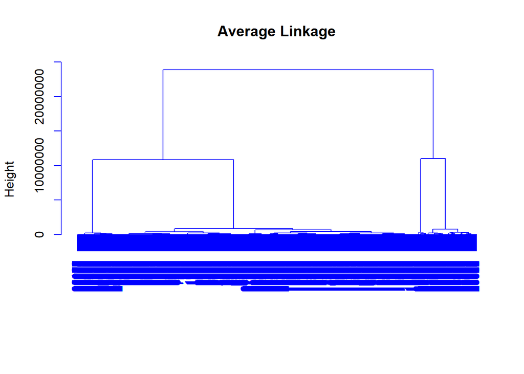

```r
plot(hc.average, main="Average Linkage", xlab="", sub="", cex=.9, col="blue")
```

```r
cut<-cutree(hc.average, 2)

# Cut of 1 is made, Cut of 2 is missed
table(kobe.train$combined_shot_type, cut)
```

```
##            cut
##                 1     2
##   Bank Shot    79    14
##   Dunk        719   104
##   Hook Shot    87    10
##   Jump Shot 13494  2292
##   Layup      3091   534
##   Tip Shot    111    22
```

#### Prediction and Confusion Matrix

```r
# HC is not particularly built for predictions, but can work yourself around your
# own elbow to get it to work

cm <- as.matrix(table(Actual=kobe.train$shot_made_flag, Predicted=cut))
HCaccuracy<-sum(diag(cm))/sum(cm)
HCaccuracy
```

```
## [1] 0.537773
```